# Assignment: Among Site (Beta) Diversity

Roy Z Moger-Reischer; Z620: Quantitative Biodiversity, Indiana University

28 January, 2017

## OVERVIEW

In this Assignment, we move beyond the investigation of within-site $\alpha$-diversity. We will explore $\beta$-diversity, which is defined as the diversity that occurs among sites. This requires that we examine the compositional similarity of assemblages that vary in space or time.

After completing this exercise you will know how to:

1. formally quantify $\beta$-diversity
2. visualize $\beta$-diversity with heatmaps, cluster analysis, and ordination
3. test hypotheses about $\beta$-diversity using multivariate statistics

## Directions:

1. Change “Student Name” on line 3 (above) with your name.
2. Complete as much of the exercise as possible during class; what you do not complete in class will need to be done on your own outside of class.
3. Use the Handout as a guide; it contains a more complete description of data sets along with the proper scripting needed to carry out the exercise.
4. Be sure to **answer the questions** in this exercise document; they also correspond to the Handout. Space for your answer is provided in this document and indicated by the “>” character. If you need a second paragraph be sure to start the first line with “>”.
5. Before you leave the classroom, **push** this file to your GitHub repo.
6. When you are done with the Assignment, **Knit** the text and code into a html file.
7. After Knitting, please submit the completed Assignment by creating a **pull request** via GitHub. Your pull request should include this file *beta_assignment.Rmd* and the html output of `Knitr` (*beta_assignment.html*).

## 1) R SETUP

Typically, the first thing you will do in either an R script or an RMarkdown file is setup your environment. This includes things such as setting the working directory and loading any packages that you will need.

In the R code chunk below, provide the code to:

1. clear your R environment,
2. print your current working directory,
3. set your working directory to your “*/Week3-Beta*” folder, and
4. load the `vegan` R package (be sure to install if needed).

```r
rm(list = ls())
getwd()
```

```
## [1] "C:/Users/rmoge/GitHub/QB2017_Moger-Reischer/Week3-Beta"
```

```r
#setwd("/Users/rzmogerr/GitHub/QB2017_Moger-Reischer/Week3-Beta")
#I'll load all of the packages, following the style of the handout
package.list <- c('vegan', 'ade4', 'viridis', 'gplots', 'BiodiversityR', 'indicspecies')
for (package in package.list) {
  if (!require(package, character.only=T, quietly=T)) {
    install.packages(package)
    library(package, character.only=T)
  }
}
```

```
## BiodiversityR 2.8-0: Use command BiodiversityRGUI() to launch the Graphical User Interface and to learn about backward compatibility
```

## 2) LOADING DATA

### Load dataset

In the R code chunk below, do the following:

1. load the `doubs` dataset from the `ade4` package, and
2. explore the structure of the dataset.

```r
data(doubs)
str(doubs)
```

```
## List of 4
##  $ env    :'data.frame': 30 obs. of  11 variables:
##   ..$ dfs: num [1:30] 3 22 102 185 215 324 268 491 705 990 ...
##   ..$ alt: num [1:30] 934 932 914 854 849 846 841 792 752 617 ...
##   ..$ slo: num [1:30] 6.18 3.43 3.64 3.5 3.18 ...
##   ..$ flo: num [1:30] 84 100 180 253 264 286 400 130 480 1000 ...
##   ..$ pH : num [1:30] 79 80 83 80 81 79 81 81 80 77 ...
##   ..$ har: num [1:30] 45 40 52 72 84 60 88 94 90 82 ...
##   ..$ pho: num [1:30] 1 2 5 10 38 20 7 20 30 6 ...
##   ..$ nit: num [1:30] 20 20 22 21 52 15 15 41 82 75 ...
##   ..$ amm: num [1:30] 0 10 5 0 20 0 0 12 12 1 ...
##   ..$ oxy: num [1:30] 122 103 105 110 80 102 111 70 72 100 ...
##   ..$ bdo: num [1:30] 27 19 35 13 62 53 22 81 52 43 ...
##  $ fish   :'data.frame': 30 obs. of  27 variables:
##   ..$ Cogo: num [1:30] 0 0 0 0 0 0 0 0 0 0 ...
##   ..$ Satr: num [1:30] 3 5 5 4 2 3 5 0 0 1 ...
##   ..$ Phph: num [1:30] 0 4 5 5 3 4 4 0 1 4 ...
##   ..$ Neba: num [1:30] 0 3 5 5 2 5 5 0 3 4 ...
##   ..$ Thth: num [1:30] 0 0 0 0 0 0 0 0 0 0 ...
##   ..$ Teso: num [1:30] 0 0 0 0 0 0 0 0 0 0 ...
##   ..$ Chna: num [1:30] 0 0 0 0 0 0 0 0 0 0 ...
##   ..$ Chto: num [1:30] 0 0 0 0 0 0 0 0 0 0 ...
##   ..$ Lele: num [1:30] 0 0 0 0 5 1 1 0 0 2 ...
##   ..$ Lece: num [1:30] 0 0 0 1 2 2 1 0 5 2 ...
##   ..$ Baba: num [1:30] 0 0 0 0 0 0 0 0 0 0 ...
##   ..$ Spbi: num [1:30] 0 0 0 0 0 0 0 0 0 0 ...
##   ..$ Gogo: num [1:30] 0 0 0 1 2 1 0 0 0 1 ...
##   ..$ Eslu: num [1:30] 0 0 1 2 4 1 0 0 0 0 ...
##   ..$ Pefl: num [1:30] 0 0 0 2 4 1 0 0 0 0 ...
##   ..$ Rham: num [1:30] 0 0 0 0 0 0 0 0 0 0 ...
##   ..$ Legi: num [1:30] 0 0 0 0 0 0 0 0 0 0 ...
##   ..$ Scer: num [1:30] 0 0 0 0 2 0 0 0 0 0 ...
##   ..$ Cyca: num [1:30] 0 0 0 0 0 0 0 0 0 0 ...
##   ..$ Titi: num [1:30] 0 0 0 1 3 2 0 0 1 0 ...
##   ..$ Abbr: num [1:30] 0 0 0 0 0 0 0 0 0 0 ...
##   ..$ Icme: num [1:30] 0 0 0 0 0 0 0 0 0 0 ...
##   ..$ Acce: num [1:30] 0 0 0 0 0 0 0 0 0 0 ...
##   ..$ Ruru: num [1:30] 0 0 0 0 5 1 0 0 4 0 ...
##   ..$ Blbj: num [1:30] 0 0 0 0 0 0 0 0 0 0 ...
##   ..$ Alal: num [1:30] 0 0 0 0 0 0 0 0 0 0 ...
##   ..$ Anan: num [1:30] 0 0 0 0 0 0 0 0 0 0 ...
##  $ xy     :'data.frame': 30 obs. of  2 variables:
##   ..$ x: num [1:30] 88 94 102 100 106 112 114 110 136 168 ...
##   ..$ y: num [1:30] 7 14 18 28 39 51 61 76 100 112 ...
##  $ species:'data.frame': 27 obs. of  4 variables:
##   ..$ Scientific: chr [1:27] "Cottus gobio" "Salmo trutta fario" "Phoxinus phoxinus" "Nemacheilus barbatulus" ...
##   ..$ French    : chr [1:27] "chabot" "truite fario" "vairon" "loche franche" ...
##   ..$ English   : chr [1:27] "european bullhead" "brown trout" "minnow" "stone loach" ...
##   ..$ code      : Factor w/ 27 levels "Abbr","Acce",..: 9 22 19 17 26 25 7 8 16 14 ...
```

```r
str(doubs$env)
```

```
## 'data.frame':    30 obs. of  11 variables:
##  $ dfs: num  3 22 102 185 215 324 268 491 705 990 ...
##  $ alt: num  934 932 914 854 849 846 841 792 752 617 ...
##  $ slo: num  6.18 3.43 3.64 3.5 3.18 ...
##  $ flo: num  84 100 180 253 264 286 400 130 480 1000 ...
##  $ pH : num  79 80 83 80 81 79 81 81 80 77 ...
##  $ har: num  45 40 52 72 84 60 88 94 90 82 ...
##  $ pho: num  1 2 5 10 38 20 7 20 30 6 ...
##  $ nit: num  20 20 22 21 52 15 15 41 82 75 ...
##  $ amm: num  0 10 5 0 20 0 0 12 12 1 ...
##  $ oxy: num  122 103 105 110 80 102 111 70 72 100 ...
##  $ bdo: num  27 19 35 13 62 53 22 81 52 43 ...
```

```r
str(doubs, max.level=1)
```

```
## List of 4
##  $ env    :'data.frame': 30 obs. of  11 variables:
##  $ fish   :'data.frame': 30 obs. of  27 variables:
##  $ xy     :'data.frame': 30 obs. of  2 variables:
##  $ species:'data.frame': 27 obs. of  4 variables:
```

```r
head(doubs)
```

```
## $env
##     dfs alt   slo  flo pH har pho nit amm oxy bdo
## 1     3 934 6.176   84 79  45   1  20   0 122  27
## 2    22 932 3.434  100 80  40   2  20  10 103  19
## 3   102 914 3.638  180 83  52   5  22   5 105  35
## 4   185 854 3.497  253 80  72  10  21   0 110  13
## 5   215 849 3.178  264 81  84  38  52  20  80  62
## 6   324 846 3.497  286 79  60  20  15   0 102  53
## 7   268 841 4.205  400 81  88   7  15   0 111  22
## 8   491 792 3.258  130 81  94  20  41  12  70  81
## 9   705 752 2.565  480 80  90  30  82  12  72  52
## 10  990 617 4.605 1000 77  82   6  75   1 100  43
## 11 1234 483 3.738 1990 81  96  30 160   0 115  27
## 12 1324 477 2.833 2000 79  86   4  50   0 122  30
## 13 1436 450 3.091 2110 81  98   6  52   0 124  24
```

[output cut: 144 more lines]

```r
print(head(doubs$fish))
```

```
##   Cogo Satr Phph Neba Thth Teso Chna Chto Lele Lece Baba Spbi Gogo Eslu
## 1    0    3    0    0    0    0    0    0    0    0    0    0    0    0
## 2    0    5    4    3    0    0    0    0    0    0    0    0    0    0
## 3    0    5    5    5    0    0    0    0    0    0    0    0    0    1
## 4    0    4    5    5    0    0    0    0    0    1    0    0    1    2
## 5    0    2    3    2    0    0    0    0    5    2    0    0    2    4
## 6    0    3    4    5    0    0    0    0    1    2    0    0    1    1
##   Pefl Rham Legi Scer Cyca Titi Abbr Icme Acce Ruru Blbj Alal Anan
## 1    0    0    0    0    0    0    0    0    0    0    0    0    0
## 2    0    0    0    0    0    0    0    0    0    0    0    0    0
## 3    0    0    0    0    0    0    0    0    0    0    0    0    0
## 4    2    0    0    0    0    1    0    0    0    0    0    0    0
## 5    4    0    0    2    0    3    0    0    0    5    0    0    0
## 6    1    0    0    0    0    2    0    0    0    1    0    0    0
```

*Question 1*: Describe some of the attributes of the `doubs` dataset.

1. How many objects are in `doubs`?
2. How many fish species are there in the `doubs` dataset?
3. How many sites are in the `doubs` dataset?

> *Answer 1a*:  
> It appears that doubs is a list of 4 substantial objects.

> *Answer 1b*:  
> There are 27 columns in the fish dataframe. Thus, 27 spp.

> *Answer 1c*:  
> There are 30 rows in that site-by-species matrix. Thus 30 sites.

### Visualizing the Doubs River Dataset

*Question 2*: Answer the following questions based on the spatial patterns of richness (i.e., $\alpha$-diversity) and Brown Trout (*Salmo trutta*) abundance in the Doubs River.

1. How does fish richness vary along the sampled reach of the Doubs River?
2. How does Brown Trout (*Salmo trutta*) abundance vary along the sampled reach of the Doubs River?
3. What do these patterns say about the limitations of using richness when examining patterns of biodiversity?

> *Answer 2a*:  
> It is perhaps a generalization, but sites tend to exhibit higher richness near mid-stream and downstream sites, compared to upstream.

> *Answer 2b*:  
> Brown trout is more abundant at upstream sites (maybe brown trout is a weak competitor?)

> *Answer 2c*:  
> Richness is a measure of numbers of different species. It doesn’t say anything about the abundances of those species. Moreover, richness doesn’t give any information about any of the individual species; rather, it gives information about the species as an aggregate. For example, even though brown trout are not present downstream (and therefore not contributing to richness), this could be a species that thrives when competitor species are absent.

## 3) QUANTIFYING BETA-DIVERSITY

In the R code chunk below, do the following:

1. write a function (`beta.w()`) to calculate Whittaker’s $\beta$-diversity (i.e., $\beta_{w}$) that accepts a site-by-species matrix with optional arguments to specify pairwise turnover between two sites, and
2. use this function to analyze various aspects of $\beta$-diversity in the Doubs River.

```r
beta.w <- function(site.by.species = "", sitenum1 = "", sitenum2 = "", pairwise = FALSE){
#  ONLY if we specify pairwise as TRUE, do this:
  if (pairwise == TRUE){
      # As a check, let's print an error if we do not provide needed arguments
    if (sitenum1 == "" | sitenum2 == "") {
      print("Error: please specify sites to compare")
      return(NA)}
# If our function made it this far, let's calculate pairwise beta diversity
    site1 = site.by.species[sitenum1,] # Select site 1
    site2 = site.by.species[sitenum2,] # Select site 2
    site1 = subset(site1, select = site1 > 0) # Removes absences
    site2 = subset(site2, select = site2 > 0) # Removes absences
    gamma = union(colnames(site1), colnames(site2)) # Gamma species pool
    s = length(gamma) # Gamma richness
    a.bar = mean(c(specnumber(site1), specnumber(site2))) # Mean sample richness
    b.w = round(s/a.bar - 1, 3)
    return(b.w)
  }
  #if there is no pairwise specification
  else{
  SbyS.pa <- decostand(site.by.species, method = "pa") # convert to presence-absence
  S <- ncol(SbyS.pa[,which(colSums(SbyS.pa) > 0)]) # number of species in region
  a.bar <- mean(specnumber(SbyS.pa)) # average richness at each site
  b.w <- round(S/a.bar, 3)
  print(a.bar)
  return(c(b.w, a.bar, S))#also return alpha, and gamma (global richness)
}
}

myab1<-beta.w(doubs$fish)
```

```
## [1] 12.5
```

```r
my2<-beta.w(doubs$fish, 1, 2,pairwise=TRUE)
my10<-beta.w(doubs$fish, 1, 10,pairwise=TRUE)
```

*Question 3*: Using your `beta.w()` function above, answer the following questions:

1. Describe how local richness ($\alpha$) and turnover ($\beta$) contribute to regional ($\gamma$) fish diversity in the Doubs.
2. Is the fish assemblage at site 1 more similar to the one at site 2 or site 10?
3. Using your understanding of the equation $\beta_{w} = \gamma/\alpha$, how would your interpretation of $\beta$ change if we instead defined beta additively (i.e., $\beta = \gamma - \alpha$)?

> *Answer 3a*:  
> We can use gamma = (alpha)(beta) = (12.5)(2.16), where alpha is the average richness across all the sites. Alpha is larger than beta, and we can say alpha contributes more to gamma.

> myab1<-beta.w(doubs$fish)

> myab1 [1] 2.16 12.50 27.00

> *Answer 3b*:  
> my2<-beta.w(doubs$fish, 1, 2,pairwise=TRUE)

> my10<-beta.w(doubs$fish, 1, 10,pairwise=TRUE)

> my2

> [1] 0.5

> my10

> [1] 0.714

> This tells me that turnover is greater between site 1 and site 10 than it is between site 1 and site 2.

> *Answer 3c*:  
> In this case, we would have beta > alpha (alpha = 12.5, beta=14.5), and the interpretation could be that alpha and beta contribute about equally to gamma.

### The Resemblance Matrix

In order to quantify $\beta$-diversity for more than two samples, we need to introduce a new primary ecological data structure: the **Resemblance Matrix**.

*Question 4*: How do incidence- and abundance-based metrics differ in their treatment of rare species? > An incidence-based matrix naturally treats rare species equally—that is, where an species is has high or low richness, it still counts as a 1 (in contradistinction to a 0). For an abundance-based matrix there is a possiblity that species with higher richness could be weighted differently than spp. represented by only a few individuals.

> *Answer 4*:

In the R code chunk below, do the following:

1. make a new object, `fish`, containing the fish abundance data for the Doubs River,
2. remove any sites where no fish were observed (i.e., rows with sum of zero),
3. construct a resemblance matrix based on SÃ¸rensen’s Similarity (“fish.ds”), and
4. construct a resemblance matrix based on Bray-Curtis Distance (“fish.db”).

```r
fish <- doubs$fish#initialie the variable
fish <- fish[-8, ] # Remove site 8 from data bc it is empty

# Calculate Bray-Curtis
fish.db <- vegdist(fish, method = "bray")
# Calculate SÃ¸rensen
fish.ds <- vegdist(fish, method = "bray", binary = TRUE)
fish.db
```

```
##             1          2          3          4          5          6
## 2  0.60000000
## 3  0.68421053 0.14285714
## 4  0.75000000 0.33333333 0.18918919
## 5  0.89189189 0.69565217 0.68000000 0.49090909
## 6  0.75000000 0.39393939 0.29729730 0.19047619 0.41818182
## 7  0.68421053 0.14285714 0.12500000 0.24324324 0.64000000 0.24324324
## 9  1.00000000 0.69230769 0.73333333 0.65714286 0.58333333 0.54285714
## 10 0.88235294 0.38461538 0.40000000 0.37142857 0.54166667 0.25714286
## 11 0.57142857 0.30434783 0.40740741 0.43750000 0.68888889 0.43750000
## 12 0.71428571 0.20000000 0.23529412 0.33333333 0.69230769 0.38461538
## 13 0.72727273 0.29032258 0.31428571 0.45000000 0.73584906 0.55000000
## 14 0.80645161 0.40000000 0.31818182 0.34693878 0.67741935 0.42857143
## 15 0.83333333 0.51111111 0.46938776 0.40740741 0.55223881 0.37037037
## 16 0.86046512 0.65384615 0.57142857 0.47540984 0.45945946 0.37704918
## 17 0.91489362 0.67857143 0.63333333 0.50769231 0.51282051 0.44615385
## 18 0.95555556 0.74074074 0.72413793 0.58730159 0.50000000 0.52380952
## 19 1.00000000 0.79310345 0.70967742 0.61194030 0.50000000 0.52238806
## 20 1.00000000 0.91176471 0.88888889 0.74025974 0.48888889 0.68831169
## 21 1.00000000 0.94594595 0.92307692 0.78313253 0.50000000 0.73493976
## 22 1.00000000 0.97619048 0.95454545 0.82795699 0.52830189 0.78494624
## 23 1.00000000 1.00000000 1.00000000 0.92000000 0.89473684 0.84000000
## 24 1.00000000 1.00000000 1.00000000 0.88888889 0.79591837 0.77777778
## 25 1.00000000 1.00000000 0.92592593 0.81250000 0.68888889 0.68750000
## 26 1.00000000 0.96363636 0.93220339 0.78125000 0.55844156 0.68750000
## 27 1.00000000 0.97333333 0.94936709 0.83333333 0.56701031 0.76190476
## 28 1.00000000 0.97560976 0.95348837 0.82417582 0.57692308 0.78021978
## 29 0.97777778 0.93939394 0.92233010 0.81481481 0.53719008 0.77777778
## 30 1.00000000 1.00000000 0.98095238 0.87272727 0.59349593 0.83636364
##             7          9         10         11         12         13
## 2
## 3
## 4
## 5
## 6
## 7
## 9  0.66666667
## 10 0.26666667 0.57142857
## 11 0.33333333 0.76000000 0.44000000
## 12 0.17647059 0.68750000 0.37500000 0.24137931
```

[output cut: 90 more lines]

```
## 16
## 17
## 18
## 19
## 20
## 21
## 22
## 23
## 24
## 25
## 26
## 27 0.18867925
## 28 0.23893805 0.09774436
## 29 0.33846154 0.18666667 0.14649682
## 30 0.36363636 0.19736842 0.15723270 0.14772727
```

```r
fish.ds
```

```
##             1          2          3          4          5          6
## 2  0.50000000
## 3  0.60000000 0.14285714
## 4  0.77777778 0.45454545 0.33333333
## 5  0.83333333 0.57142857 0.46666667 0.15789474
## 6  0.81818182 0.53846154 0.42857143 0.11111111 0.04761905
## 7  0.66666667 0.25000000 0.33333333 0.38461538 0.37500000 0.33333333
## 9  1.00000000 0.50000000 0.55555556 0.38461538 0.37500000 0.33333333
## 10 0.71428571 0.33333333 0.40000000 0.28571429 0.29411765 0.25000000
## 11 0.71428571 0.33333333 0.40000000 0.42857143 0.52941176 0.50000000
## 12 0.71428571 0.33333333 0.40000000 0.42857143 0.52941176 0.50000000
## 13 0.71428571 0.33333333 0.40000000 0.57142857 0.64705882 0.62500000
## 14 0.81818182 0.53846154 0.42857143 0.33333333 0.42857143 0.40000000
## 15 0.83333333 0.57142857 0.60000000 0.36842105 0.36363636 0.33333333
## 16 0.88888889 0.70000000 0.61904762 0.36000000 0.28571429 0.25925926
## 17 0.91304348 0.76000000 0.69230769 0.46666667 0.39393939 0.37500000
## 18 0.91666667 0.76923077 0.70370370 0.48387097 0.41176471 0.39393939
## 19 1.00000000 0.84615385 0.77777778 0.54838710 0.41176471 0.45454545
## 20 1.00000000 0.84000000 0.76923077 0.53333333 0.39393939 0.43750000
## 21 1.00000000 0.84615385 0.77777778 0.54838710 0.41176471 0.45454545
## 22 1.00000000 0.92000000 0.84615385 0.60000000 0.45454545 0.50000000
## 23 1.00000000 1.00000000 1.00000000 0.81818182 0.71428571 0.69230769
## 24 1.00000000 1.00000000 1.00000000 0.75000000 0.68421053 0.66666667
## 25 1.00000000 1.00000000 0.83333333 0.62500000 0.36842105 0.44444444
## 26 1.00000000 0.91666667 0.84000000 0.58620690 0.43750000 0.48387097
## 27 1.00000000 0.92000000 0.84615385 0.60000000 0.45454545 0.50000000
## 28 1.00000000 0.92000000 0.84615385 0.60000000 0.45454545 0.50000000
## 29 0.92592593 0.79310345 0.73333333 0.52941176 0.40540541 0.44444444
## 30 1.00000000 1.00000000 0.92000000 0.65517241 0.50000000 0.54838710
##             7          9         10         11         12         13
## 2
## 3
## 4
## 5
## 6
## 7
## 9  0.40000000
## 10 0.09090909 0.45454545
## 11 0.27272727 0.45454545 0.33333333
## 12 0.27272727 0.45454545 0.33333333 0.00000000
```

[output cut: 90 more lines]

```
## 16
## 17
## 18
## 19
## 20
## 21
## 22
## 23
## 24
## 25
## 26
## 27 0.02325581
## 28 0.02325581 0.00000000
## 29 0.10638298 0.08333333 0.08333333
## 30 0.04761905 0.02325581 0.02325581 0.10638298
```

```r
fish.db <- vegdist(fish, method = "bray", upper = TRUE, diag = TRUE)
fish.ds <- vegdist(fish, method = "bray", upper = TRUE, binary = TRUE, diag = TRUE)
```

*Question 5*: Using the distance matrices from above, answer the following questions:

1. Does the resemblance matrix (`fish.db`) represent similarity or dissimilarity? What information in the resemblance matrix led you to arrive at your answer?
2. Compare the resemblance matrices (`fish.db` or `fish.ds`) you just created. How does the choice of the SÃ¸rensen or Bray-Curtis distance influence your interpretation of site (dis)similarity?

> *Answer 5a*:  
> I wanted to use the numbers on the 1:1 diagonal to indicate which type of resemblance matrix. That is, if the resemblance of each site to itself is 1, it is a similarity matrix; if it is 0, the matrix measure dissimilarity. However, R didn’t show that diagonal without specifying dag = TRUE. I looked at the handout, where it is indicated that Bray-Curtis is a Dissimilarity metric. This makes sense, because the numerator is a difference. Therefore, if for a given site, variable in the numerator is subtracted from itself, the difference will equal 0, and the sum of the 0s will give a dissimilarity of 0.

> *Answer 5b*: It was not easy to intuitively compare the matrices without using some sort of visualization. I couldn’t detect major differences just by looking at the numerical outputs of those matrices. The two methods seemed to output comparable results.

## 4) VISUALIZING BETA-DIVERSITY

### A. Heatmaps

In the R code chunk below, do the following:

1. define a color palette,
2. define the order of sites in the Doubs River, and
3. use the `levelplot()` function to create a heatmap of fish abundances in the Doubs River.

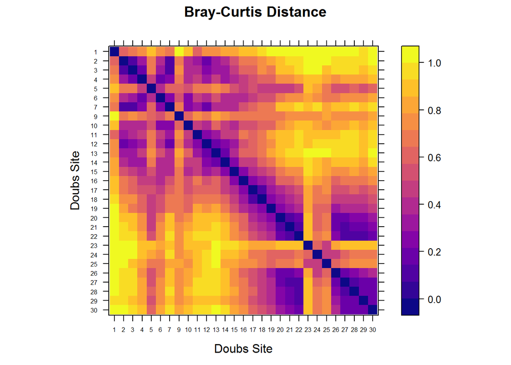

```r
library(viridis)
order <- rev(attr(fish.db, "Labels"))#define a reversed order
levelplot(as.matrix(fish.db)[, order], aspect = "iso", col.regions = plasma, xlab = "Doubs Site", ylab = "Doubs Site", scales = list(cex = 0.5), main = "Bray-Curtis Distance")
```

### B. Cluster Analysis

In the R code chunk below, do the following:

1. perform a cluster analysis using Ward’s Clustering, and
2. plot your cluster analysis (use either `hclust` or `heatmap.2`).

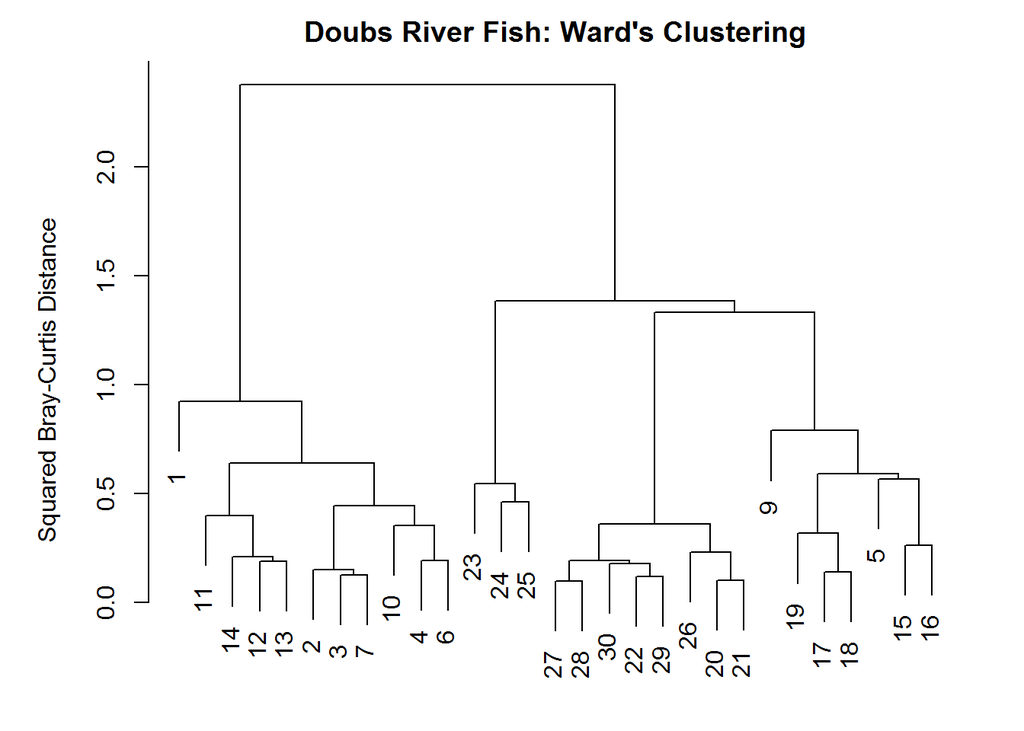

```r
fish.ward <- hclust(fish.db, method = "ward.D2")#now visualize phylogenetically
par(mar = c(1, 5, 2, 2) + 0.1)#set up display settings
plot(fish.ward, main = "Doubs River Fish: Ward's Clustering",ylab = "Squared Bray-Curtis Distance")#plot the tree
```

```r
#I like that this tree is not ultrametric
```

*Question 6*: Based on cluster analyses and the introductory plots that we generated after loading the data, develop an ecological hypothesis for fish diversity the `doubs` data set?

> This hypothesis could be (in)validated by plotting the site identifier numbers on the x-y space map.

> If the site numbers correspond 1 through 30 to sites most Upstream through most Downstream (and based on section 5A, I think this is true), then my hypothesis is somewhat supported: The cluster on the left is mostly Upstream sties; there is a small Midstream/Downstream clade of 3; on the right is a Midstream clade; in the middle-right is a Downstream clade.

> The clades are less visible on the heatmap.

### Principal Coordinates Analysis (PCoA)

In the R code chunk below, do the following:

1. perform a Principal Coordinates Analysis to visualize beta-diversity
2. calculate the variation explained by the first three axes in your ordination
3. plot the PCoA ordination,
4. label the sites as points using the Doubs River site number, and
5. identify influential species and add species coordinates to PCoA plot.

```r
fish.pcoa <- cmdscale(fish.db, eig = TRUE, k = 3)#do the PCoA
str(fish.pcoa)
```

```
## List of 5
##  $ points: num [1:29, 1:3] -0.3204 -0.5027 -0.4721 -0.3163 0.0666 ...
##   ..- attr(*, "dimnames")=List of 2
##   .. ..$ : chr [1:29] "1" "2" "3" "4" ...
##   .. ..$ : NULL
##  $ eig   : num [1:29] 3.695 1.098 0.71 0.415 0.305 ...
##  $ x     : NULL
##  $ ac    : num 0
##  $ GOF   : num [1:2] 0.748 0.78
```

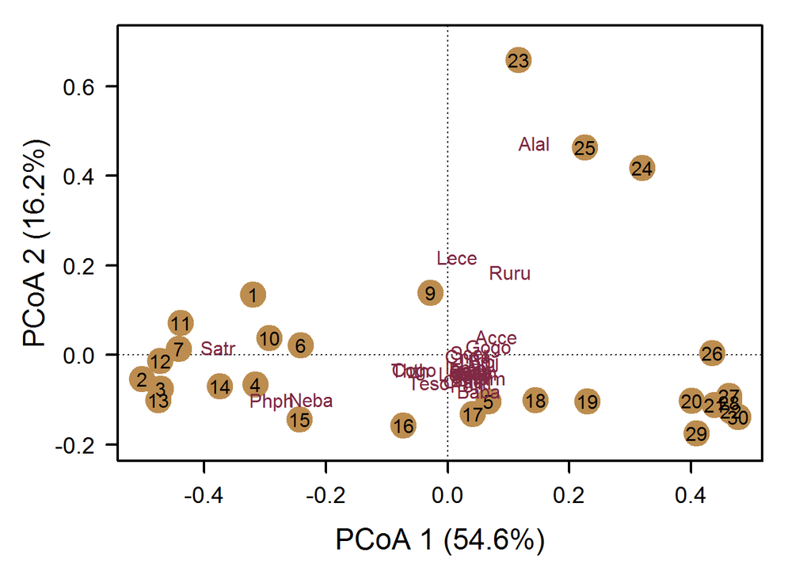

```r
explainvar1 <- round(fish.pcoa$eig[1] / sum(fish.pcoa$eig), 3) * 100#for each of the first three eigenvalues, assess what proportion of variance it explains
explainvar2 <- round(fish.pcoa$eig[2] / sum(fish.pcoa$eig), 3) * 100
explainvar3 <- round(fish.pcoa$eig[3] / sum(fish.pcoa$eig), 3) * 100
sum.eig <- sum(explainvar1, explainvar2, explainvar3)#total amt explained in these 3 dimensions

par(mar = c(5, 5, 1, 2) + 0.1)#structure the figure output
# Initiate Plot
plot(fish.pcoa$points[ ,1], fish.pcoa$points[ ,2], ylim = c(-0.2, 0.7), xlab = paste("PCoA 1 (", explainvar1, "%)", sep = ""), ylab = paste("PCoA 2 (", explainvar2, "%)", sep = ""), pch = 16, cex = 2.0, type = "n", cex.lab = 1.5, cex.axis = 1.2, axes = FALSE)
# Add Axes
axis(side = 1, labels = T, lwd.ticks = 2, cex.axis = 1.2, las = 1)
axis(side = 2, labels = T, lwd.ticks = 2, cex.axis = 1.2, las = 1)
abline(h = 0, v = 0, lty = 3)
box(lwd = 2)
# Add Points & Labels
points(fish.pcoa$points[ ,1], fish.pcoa$points[ ,2],
pch = 19, cex = 3, bg = "#bc8d4f", col = "#bc8d4f")
text(fish.pcoa$points[ ,1], fish.pcoa$points[ ,2],
labels = row.names(fish.pcoa$points))
#Now IDfy the most influential spp
fishREL <- fish
  for(i in 1:nrow(fish)){
    fishREL[i, ] = fish[i, ] / sum(fish[i, ])
    }

fish.pcoa <- add.spec.scores(fish.pcoa,fishREL,method = "pcoa.scores")
text(fish.pcoa$cproj[ ,1], fish.pcoa$cproj[ ,2],labels = row.names(fish.pcoa$cproj), col = "#802944")
```

In the R code chunk below, do the following:

1. identify influential species based on correlations along each PCoA axis (use a cutoff of 0.70), and
2. use a permutation test (999 permutations) to test the correlations of each species along each axis.

```r
spe.corr <- add.spec.scores(fish.pcoa, fishREL, method = "cor.scores")$cproj
corrcut <- 0.7 # user defined cutoff
imp.spp <- spe.corr[abs(spe.corr[, 1]) >= corrcut | abs(spe.corr[, 2]) >= corrcut, ]#now get those spp above the cutoff
print(imp.spp)#and print the latter list
```

```
##            Dim1       Dim2        Dim3
## Phph -0.8674640 -0.1699316 -0.12463098
## Neba -0.7674114 -0.1855678 -0.36963830
## Rham  0.8088751 -0.4192567  0.14136301
## Legi  0.8201759 -0.1701803  0.12423941
## Cyca  0.7595122 -0.4442926  0.17313658
## Abbr  0.7704744 -0.3452714  0.29277803
## Acce  0.7635195  0.2155765  0.10288179
## Blbj  0.8118483 -0.1324698  0.25581178
## Alal  0.4471283  0.8119843 -0.05167131
## Anan  0.7974122 -0.3918972  0.20944968
```

```r
#do a permut'n test for species abundance across axes
fit <- envfit(fish.pcoa, fishREL, perm = 999)
```

*Question 7*: Address the following questions about the ordination results of the `doubs` data set:

1. Describe the grouping of sites in the Doubs River based on fish community composition.
2. Generate a hypothesis about which fish species are potential indicators of river quality.

> The sites cluster similarly in the PCoA as they did in the Ward’s Clustering.

> One could posit a similar hypothesis that the clustering is related to geographic upstream/downstream distance. If the site numbers correspond 1 through 30 to sites most Upstream through most Downstream (and based on section 5A, I think this is true), this hypothesis would be somewhat supported.

> *Answer 7b*:  
> Perhaps it would make sense to focus on the most-influential species. The correlation coefficient test indicated that Phph, Neba, Rham, Legi, Cyca, Abbr, Acce, Blbj, Alal, and Anan spp exhibited a correlation coefficiant > 0.7 along at least PCoA dimension. Whether or not these species are particularly sensitive to changes in water quality, I think that even if these spp. are equally sensitive to water quality as other fish spp., if there is a response by the stream organisms, it would be more easily detectable in these species.